# Quality Control in Semiconductor Manufacturing

IM39202: Statistical Learning Laboratory — Spring 2026 | Group 3

2026-04-16

# 1 Introduction

Semiconductor fabrication is one of the most complex manufacturing processes in the world, involving hundreds of sequential steps monitored by thousands of sensors. A single process deviation can lead to defective wafers, causing significant yield loss and financial cost.

**Objective:** Using the SECOM dataset, build a binary classification pipeline to predict whether a wafer lot **passes** or **fails** quality inspection, and identify the sensors most responsible for process failures.

**Key challenges addressed:**

- **Extreme class imbalance** — only ~6.6% of lots are failures; naive models simply predict “pass” every time
- **High dimensionality** — 590 sensor features, many redundant or uninformative
- **Pervasive missing values** — some sensors are missing for over 50% of observations

# 2 Literature Review

Semiconductor yield prediction has attracted significant ML research:

- **Chien et al. (2007)** applied neural networks and decision trees for fault detection in wafer fabrication, emphasising that sensor selection is as important as model choice.
- **Susto et al. (2015)** (*IEEE Trans. Automation Sci. & Eng.*) proposed multi-step machine learning for predictive maintenance, showing that Random Forests outperform SVMs when class imbalance is properly addressed.
- **He & Garcia (2009)** (*IEEE TKDE*) surveyed imbalanced learning; SMOTE/ROSE combined with ensemble classifiers consistently outperforms simple resampling on industrial datasets.
- **Hsu & Chien (2007)** demonstrated that removing redundant sensors before classification reduces noise and improves generalisation on SECOM-like settings.

These findings motivate our pipeline: aggressive feature reduction → ROSE oversampling inside cross-validation → ensemble classifiers, evaluated on F1 and ROC-AUC for the **fail** class.

# 3 Dataset Description

## 3.1 Loading the Data

```r
# Place secom.data and secom_labels.data in: C:/Users/Jayanshu Jena/Desktop/SL LAB/Lab Exam
X_raw  <- read.table("secom.data",        header = FALSE, na.strings = "NaN")
labels <- read.table("secom_labels.data", header = FALSE)

colnames(X_raw) <- paste0("S", seq_len(ncol(X_raw)))

# Recode -1 → "Pass",  1 → "Fail"
y <- factor(ifelse(labels$V1 == -1, "Pass", "Fail"), levels = c("Pass", "Fail"))

cat("Dimensions:", nrow(X_raw), "rows ×", ncol(X_raw), "columns\n")
```

```
## Dimensions: 1567 rows × 590 columns
```

```r
cat("Class distribution:\n"); print(table(y))
```

```
## Class distribution:
```

```
## y
## Pass Fail
## 1463  104
```

```r
cat("Failure rate:", round(mean(y == "Fail") * 100, 2), "%\n")
```

```
## Failure rate: 6.64 %
```

## 3.2 Missing Values

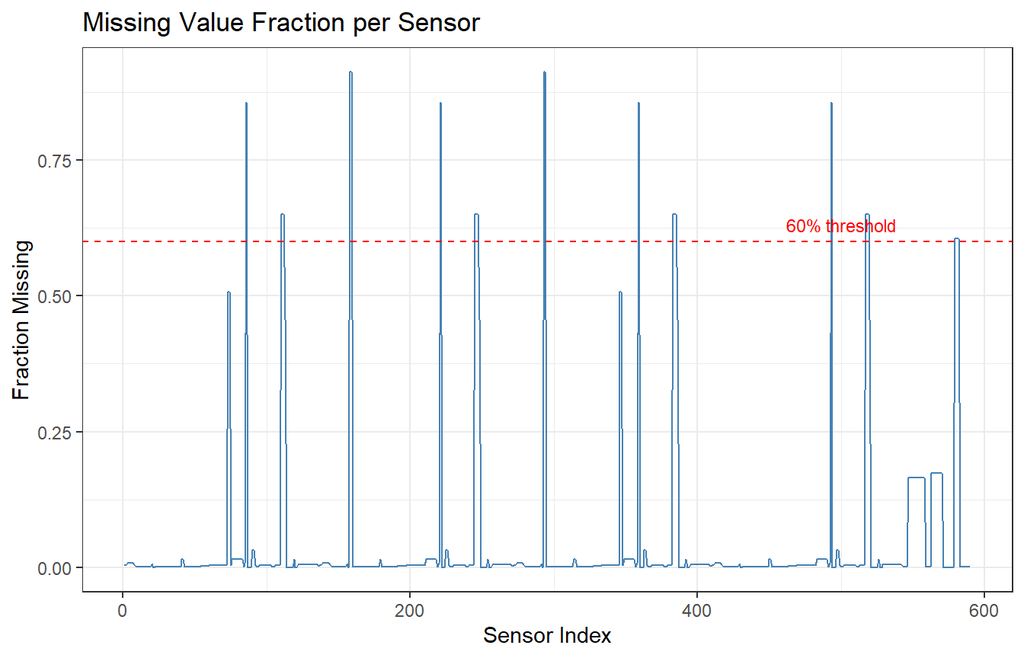

Fraction of missing values per sensor feature.

```r
miss_frac <- colMeans(is.na(X_raw))

tibble(sensor = seq_along(miss_frac), missing = miss_frac) |>
  ggplot(aes(sensor, missing)) +
  geom_line(colour = "steelblue", linewidth = 0.4) +
  geom_hline(yintercept = 0.6, colour = "red", linetype = "dashed") +
  annotate("text", x = 500, y = 0.63, label = "60% threshold", colour = "red", size = 3) +
  labs(title = "Missing Value Fraction per Sensor",
       x = "Sensor Index", y = "Fraction Missing") +
  theme_bw()
```

```r
cat("Features > 60% missing (to be dropped):", sum(miss_frac > 0.6), "\n")
```

```
## Features > 60% missing (to be dropped): 24
```

## 3.3 Class Imbalance

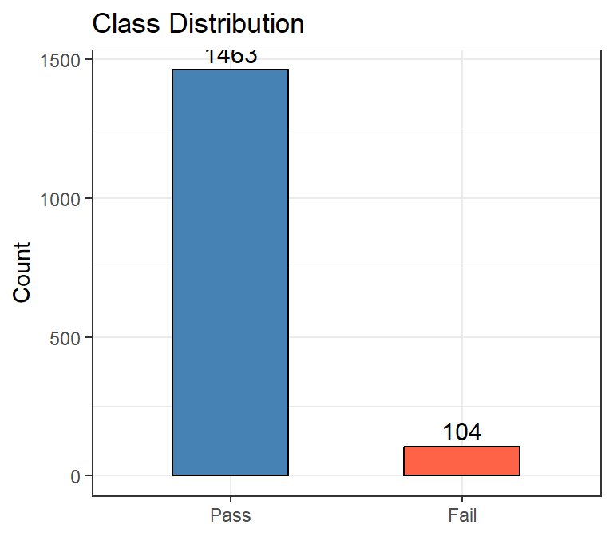

Severe class imbalance — failures are only ~6.6% of all lots.

```r
as.data.frame(table(y)) |>
  ggplot(aes(y, Freq, fill = y)) +
  geom_col(colour = "black", width = 0.5) +
  geom_text(aes(label = Freq), vjust = -0.4, size = 4) +
  scale_fill_manual(values = c("steelblue", "tomato")) +
  labs(title = "Class Distribution", x = NULL, y = "Count") +
  theme_bw() + theme(legend.position = "none")
```

The dataset is heavily imbalanced. Accuracy is therefore a **misleading** metric — a model that always predicts “Pass” achieves > 93% accuracy but detects zero failures. All model selection uses **ROC-AUC** and **F1 for the fail class**.

# 4 Methodologies

## 4.1 Preprocessing

```r
# 1. Drop columns with > 60% missing
X <- X_raw[, miss_frac <= 0.6]
cat("After removing high-missing columns:", ncol(X), "features\n")
```

```
## After removing high-missing columns: 566 features
```

```r
# 2. Median imputation
X <- as.data.frame(
  lapply(X, function(col) {
    col[is.na(col)] <- median(col, na.rm = TRUE)
    col
  })
)

# 3. Remove near-zero variance features
nzv_idx <- nearZeroVar(X)
if (length(nzv_idx) > 0) X <- X[, -nzv_idx]
cat("After near-zero variance removal:", ncol(X), "features\n")
```

```
## After near-zero variance removal: 439 features
```

```r
# 4. Stratified 80/20 train/test split
train_idx <- createDataPartition(y, p = 0.8, list = FALSE)
X_train <- X[train_idx, ];  y_train <- y[train_idx]
X_test  <- X[-train_idx, ]; y_test  <- y[-train_idx]

train_df <- data.frame(X_train, Class = y_train)

cat("Train:", nrow(X_train), "| Test:", nrow(X_test), "\n")
```

```
## Train: 1255 | Test: 312
```

```r
cat("Train fail rate:", round(mean(y_train == "Fail") * 100, 2), "%\n")
```

```
## Train fail rate: 6.69 %
```

## 4.2 Handling Class Imbalance

**ROSE** (Random Over-Sampling Examples) is applied *inside* each cross-validation fold via `trainControl(sampling = "rose")`. This prevents data leakage — the oversampled minority class examples are only generated from training fold data, never from the held-out fold.

## 4.3 Training Control

```r
ctrl <- trainControl(
  method          = "cv",
  number          = 5,
  classProbs      = TRUE,
  summaryFunction = twoClassSummary,  # reports ROC, Sens, Spec
  sampling        = "rose",           # ROSE oversampling per fold
  savePredictions = "final"
)
```

## 4.4 Model 1 — Regularised Logistic Regression (Elastic Net)

Logistic regression with LASSO/Ridge penalty handles the large feature space and provides interpretable coefficients. The mixing parameter `alpha` and regularisation strength `lambda` are tuned over a small grid.

```r
lr_grid <- expand.grid(
  alpha  = c(0, 0.5, 1),
  lambda = 10^seq(-3, 0, length.out = 5)
)

fit_lr <- train(
  Class ~ ., data = train_df,
  method     = "glmnet",
  family     = "binomial",
  trControl  = ctrl,
  tuneGrid   = lr_grid,
  metric     = "ROC",
  preProcess = c("center", "scale")
)
cat("Best LR params:"); print(fit_lr$bestTune)
```

```
## Best LR params:
```

```
##    alpha     lambda
## 13     1 0.03162278
```

## 4.5 Model 2 — Random Forest

An ensemble of 200 decision trees; robust to noisy sensors. Feature importance is obtained from mean decrease in node impurity across all trees.

```r
rf_grid <- expand.grid(mtry = c(10, 20, 30))

fit_rf <- train(
  Class ~ ., data = train_df,
  method     = "rf",
  ntree      = 200,
  trControl  = ctrl,
  tuneGrid   = rf_grid,
  metric     = "ROC",
  preProcess = c("center", "scale")
)
cat("Best RF mtry:"); print(fit_rf$bestTune)
```

```
## Best RF mtry:
```

```
##   mtry
## 1   10
```

## 4.6 Model 3 — Gradient Boosting Machine

```r
gbm_grid <- expand.grid(
  n.trees           = c(100, 200),
  interaction.depth = c(2, 3),
  shrinkage         = 0.05,
  n.minobsinnode    = 10
)

fit_gbm <- train(
  Class ~ ., data = train_df,
  method     = "gbm",
  trControl  = ctrl,
  tuneGrid   = gbm_grid,
  metric     = "ROC",
  preProcess = c("center", "scale"),
  verbose    = FALSE
)
```

```r
cat("Best GBM params:"); print(fit_gbm$bestTune)
```

```
## Best GBM params:
```

```
##   n.trees interaction.depth shrinkage n.minobsinnode
## 1     100                 2      0.05             10
```

## 4.7 Model 4 — Support Vector Machine (RBF Kernel)

Maximum-margin classifier with an RBF kernel; `class.weights` handles imbalance alongside ROSE.

```r
svm_grid <- expand.grid(sigma = c(0.001, 0.01), C = c(1, 10))

fit_svm <- train(
  Class ~ ., data = train_df,
  method     = "svmRadial",
  trControl  = ctrl,
  tuneGrid   = svm_grid,
  metric     = "ROC",
  preProcess = c("center", "scale"),
  class.weights = c(Pass = 1, Fail = 10)
)
cat("Best SVM params:"); print(fit_svm$bestTune)
```

```
## Best SVM params:
```

```
##   sigma C
## 3  0.01 1
```

# 5 Comparison

## 5.1 Predictions on the Test Set

```r
predict_model <- function(fit, X_test, y_test) {
  pred_class <- predict(fit, newdata = X_test)
  pred_prob  <- predict(fit, newdata = X_test, type = "prob")[, "Fail"]

  cm  <- confusionMatrix(pred_class, y_test, positive = "Fail")
  auc <- roc(y_test, pred_prob, quiet = TRUE)$auc
  f1  <- cm$byClass["F1"]

  list(pred_class = pred_class, pred_prob = pred_prob,
       cm = cm, auc = as.numeric(auc), f1 = as.numeric(f1))
}

res_lr  <- predict_model(fit_lr,  X_test, y_test)
res_rf  <- predict_model(fit_rf,  X_test, y_test)
res_gbm <- predict_model(fit_gbm, X_test, y_test)
res_svm <- predict_model(fit_svm, X_test, y_test)
```

## 5.2 Metrics Table

```r
metrics <- tibble(
  Model = c("Logistic Regression", "Random Forest",
            "Gradient Boosting",  "SVM (RBF)"),
  `ROC-AUC`    = c(res_lr$auc,  res_rf$auc,  res_gbm$auc,  res_svm$auc),
  `F1 (Fail)`  = c(res_lr$f1,   res_rf$f1,   res_gbm$f1,   res_svm$f1),
  Sensitivity  = c(res_lr$cm$byClass["Sensitivity"],
                   res_rf$cm$byClass["Sensitivity"],
                   res_gbm$cm$byClass["Sensitivity"],
                   res_svm$cm$byClass["Sensitivity"]),
  Specificity  = c(res_lr$cm$byClass["Specificity"],
                   res_rf$cm$byClass["Specificity"],
                   res_gbm$cm$byClass["Specificity"],
                   res_svm$cm$byClass["Specificity"])
) |> mutate(across(where(is.numeric), \(x) round(x, 4)))

kable(metrics, caption = "Test-set performance metrics for all models.",
      booktabs = TRUE, align = "lcccc") |>
  kable_styling(latex_options = c("striped", "hold_position"), full_width = FALSE)
```

Test-set performance metrics for all models.

| Model | ROC-AUC | F1 (Fail) | Sensitivity | Specificity |
| --- | --- | --- | --- | --- |
| Logistic Regression | 0.7038 | 0.2185 | 0.65 | 0.7055 |
| Random Forest | 0.5333 | 0.1208 | 1.00 | 0.0034 |
| Gradient Boosting | 0.4920 | 0.1208 | 1.00 | 0.0034 |
| SVM (RBF) | 0.5457 | 0.0833 | 0.10 | 0.9110 |

## 5.3 ROC Curves

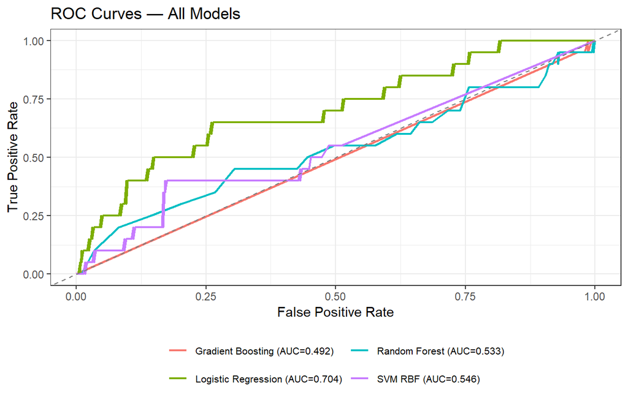

ROC curves for all four classifiers on the test set.

```r
roc_lr  <- roc(y_test, res_lr$pred_prob,  quiet = TRUE)
roc_rf  <- roc(y_test, res_rf$pred_prob,  quiet = TRUE)
roc_gbm <- roc(y_test, res_gbm$pred_prob, quiet = TRUE)
roc_svm <- roc(y_test, res_svm$pred_prob, quiet = TRUE)

roc_df <- bind_rows(
  tibble(FPR = 1 - roc_lr$specificities,  TPR = roc_lr$sensitivities,
         Model = paste0("Logistic Regression (AUC=", round(auc(roc_lr),  3), ")")),
  tibble(FPR = 1 - roc_rf$specificities,  TPR = roc_rf$sensitivities,
         Model = paste0("Random Forest (AUC=",       round(auc(roc_rf),  3), ")")),
  tibble(FPR = 1 - roc_gbm$specificities, TPR = roc_gbm$sensitivities,
         Model = paste0("Gradient Boosting (AUC=",   round(auc(roc_gbm), 3), ")")),
  tibble(FPR = 1 - roc_svm$specificities, TPR = roc_svm$sensitivities,
         Model = paste0("SVM RBF (AUC=",             round(auc(roc_svm), 3), ")"))
)

ggplot(roc_df, aes(FPR, TPR, colour = Model)) +
  geom_line(linewidth = 0.8) +
  geom_abline(slope = 1, intercept = 0, linetype = "dashed", colour = "grey50") +
  labs(title = "ROC Curves — All Models", x = "False Positive Rate",
       y = "True Positive Rate") +
  theme_bw() +
  theme(legend.position = "bottom", legend.text = element_text(size = 8),
        legend.title = element_blank()) +
  guides(colour = guide_legend(ncol = 2))
```

## 5.4 Confusion Matrices

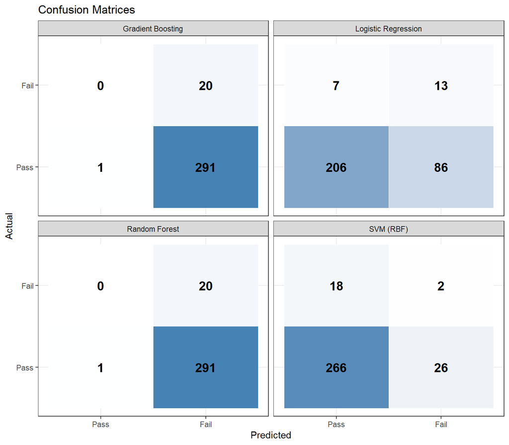

Confusion matrices for all four models on the test set.

```r
cm_to_df <- function(cm, model_name) {
  as.data.frame(cm$table) |>
    mutate(Model = model_name)
}

cm_df <- bind_rows(
  cm_to_df(res_lr$cm,  "Logistic Regression"),
  cm_to_df(res_rf$cm,  "Random Forest"),
  cm_to_df(res_gbm$cm, "Gradient Boosting"),
  cm_to_df(res_svm$cm, "SVM (RBF)")
)

ggplot(cm_df, aes(Prediction, Reference, fill = Freq)) +
  geom_tile(colour = "white") +
  geom_text(aes(label = Freq), size = 5, fontface = "bold") +
  scale_fill_gradient(low = "white", high = "steelblue") +
  facet_wrap(~Model, ncol = 2) +
  labs(title = "Confusion Matrices", x = "Predicted", y = "Actual") +
  theme_bw() +
  theme(legend.position = "none")
```

**Key observation:** In manufacturing, **false negatives** (failed lots shipped as passes) are far more costly than false positives. Models should be evaluated and thresholds tuned to minimise false negatives — even at the cost of higher false positives.

## 5.5 5-Fold CV Resampling Comparison

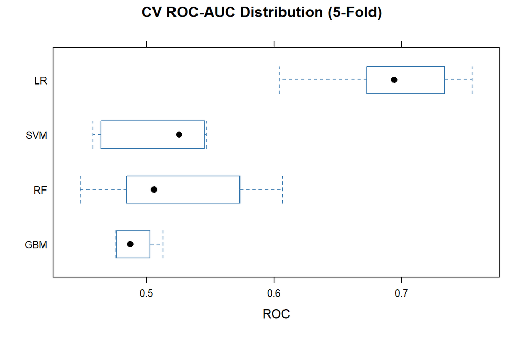

5-fold cross-validation ROC-AUC distributions across models.

```r
cv_results <- resamples(list(
  LR  = fit_lr,
  RF  = fit_rf,
  GBM = fit_gbm,
  SVM = fit_svm
))

bwplot(cv_results, metric = "ROC",
       main = "CV ROC-AUC Distribution (5-Fold)",
       par.settings = list(box.rectangle  = list(col = "steelblue"),
                           box.umbrella   = list(col = "steelblue"),
                           plot.symbol    = list(col = "steelblue")))
```

# 6 Insights

## 6.1 Feature Importance (Random Forest)

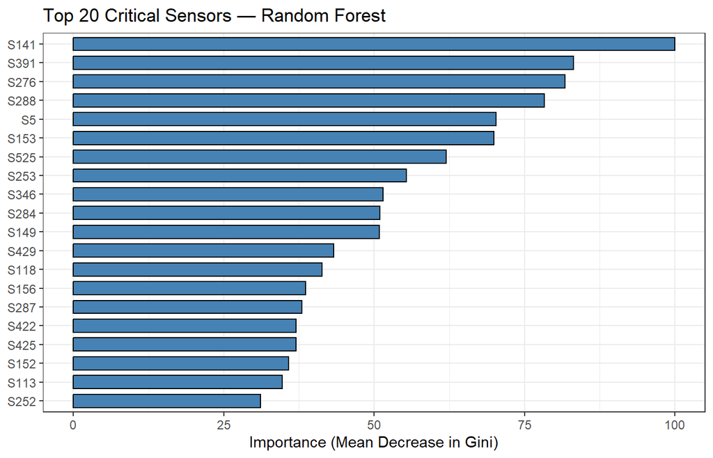

Top 20 sensors by Random Forest mean decrease in Gini impurity.

```r
imp <- varImp(fit_rf)$importance |>
  rownames_to_column("Sensor") |>
  arrange(desc(Overall)) |>
  slice_head(n = 20)

ggplot(imp, aes(x = reorder(Sensor, Overall), y = Overall)) +
  geom_col(fill = "steelblue", colour = "black", width = 0.7) +
  coord_flip() +
  labs(title = "Top 20 Critical Sensors — Random Forest",
       x = NULL, y = "Importance (Mean Decrease in Gini)") +
  theme_bw()
```

```r
cat("Top 10 critical sensors:\n")
```

```
## Top 10 critical sensors:
```

```r
print(imp |> select(Sensor, Overall) |> slice_head(n = 10))
```

```
##    Sensor   Overall
## 1    S141 100.00000
## 2    S391  83.18006
## 3    S276  81.70758
## 4    S288  78.28063
## 5      S5  70.23392
## 6    S153  69.87848
## 7    S525  61.94601
## 8    S253  55.37819
## 9    S346  51.48019
## 10   S284  50.97878
```

## 6.2 Variable Influence & Managerial Implications

The analysis reveals several actionable insights for process engineers:

[output not shown]

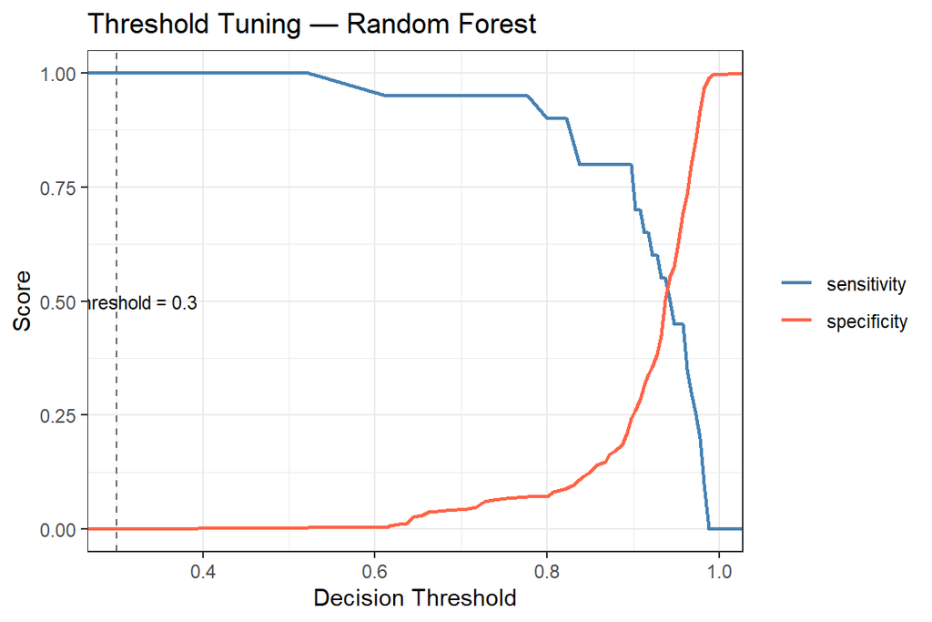

Sensitivity vs. Specificity trade-off for Random Forest at different thresholds.

```r
roc_rf_obj <- roc(y_test, res_rf$pred_prob, quiet = TRUE)
coords_df  <- coords(roc_rf_obj, "all", ret = c("threshold","sensitivity","specificity")) |>
  as_tibble()

coords_df |>
  pivot_longer(c(sensitivity, specificity), names_to = "Metric", values_to = "Value") |>
  ggplot(aes(threshold, Value, colour = Metric)) +
  geom_line(linewidth = 0.8) +
  geom_vline(xintercept = 0.3, linetype = "dashed", colour = "grey40") +
  annotate("text", x = 0.32, y = 0.5, label = "Threshold = 0.3", size = 3) +
  labs(title = "Threshold Tuning — Random Forest",
       x = "Decision Threshold", y = "Score") +
  scale_colour_manual(values = c("steelblue", "tomato")) +
  theme_bw() +
  theme(legend.title = element_blank())
```

# 7 Conclusion

## 7.2 Limitations

- The SECOM dataset contains no sensor metadata, so identified critical sensors cannot be mapped to specific process modules without domain knowledge.
- SMOTE/ROSE can generate synthetic samples that blur the true decision boundary; more real failure data would improve model reliability.
- Temporal ordering of wafer lots is ignored. A time-aware model (e.g., ARIMA on sensor drift, or LSTM) could capture gradual process degradation before failures occur.

## 7.3 Potential Industrial Applications

- **Inline defect flagging:** Score each lot in real time; trigger re-inspection if P(Fail) exceeds a business-tuned threshold.
- **Sensor rationalisation:** Retire uninformative sensors to cut costs and reduce system complexity.
- **Root-cause navigation:** Use top-importance sensors to guide engineers to the most likely failure process module — reducing mean-time-to-diagnose.
- **Predictive maintenance:** Monitor drift in critical sensor distributions to schedule tool maintenance before yield loss materialises.

# 8 Appendix — Package Versions

```r
si <- sessionInfo()
pkg_versions <- tibble(
  Package = c("caret", "randomForest", "gbm", "kernlab",
              "pROC", "ROSE", "glmnet", "tidyverse"),
  Version = sapply(c("caret", "randomForest", "gbm", "kernlab",
                     "pROC", "ROSE", "glmnet", "tidyverse"),
                   function(p) as.character(packageVersion(p)))
)
kable(pkg_versions, booktabs = TRUE, caption = "R package versions used.") |>
  kable_styling(latex_options = "hold_position", full_width = FALSE)
```

R package versions used.

| Package | Version |
| --- | --- |
| caret | 7.0.1 |
| randomForest | 4.7.1.2 |
| gbm | 2.2.3 |
| kernlab | 0.9.33 |
| pROC | 1.19.0.1 |
| ROSE | 0.0.4 |
| glmnet | 4.1.10 |
| tidyverse | 2.0.0 |